# Classification 1

## K-Nearest Neighbours

4. **Create class predictions for the test set using the `knn()` function. Use `student`, `balance`, and `income` (but no basis functions of those variables) in the `default_train` dataset. Set `k` to 5. Store the predictions in a variable called `knn_5_pred`.**

```r
knn_5_pred <- knn(train = default_train %>% select(-default), test = default_test %>% select(-default), cl = default_train$default, k = 5)
knn_5_pred
```

[output not shown]

[output cut: 98 more lines]

5. **Create two scatter plots with income and balance as in the first plot you made. One with the true class (`default`) mapped to the colour aesthetic, and one with the predicted class (`knn_5_pred`) mapped to the colour aesthetic.**

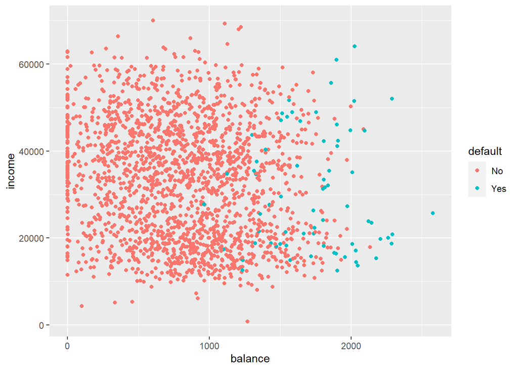

```r
default_test <-
  default_test %>%
  mutate(knn_5_pred = knn_5_pred)

default_test %>%
  ggplot(mapping = aes(x = balance, y = income, color = default)) +
  geom_point()
```

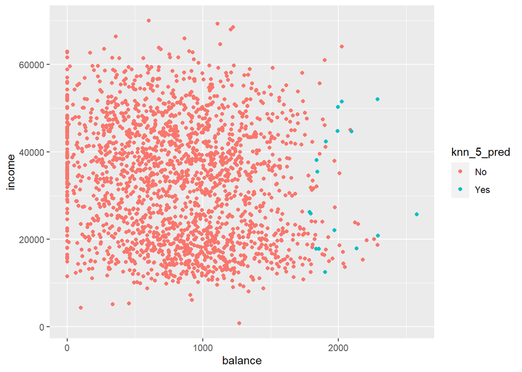

```r
default_test %>%
  ggplot(mapping = aes(x = balance, y = income, color = knn_5_pred)) +
  geom_point()
```

The test data set seems to have more Yeses than the prediction, but it seems mostly right.

6. **Repeat the same steps, but now with a `knn_2_pred` vector generated from a 2-nearest neighbours algorithm. Are there any differences?**

```r
knn_2_pred <- knn(train = default_train %>% select(-default), test = default_test %>% select(-default, -knn_5_pred), cl = default_train$default, k = 2)

default_test %>%
  mutate(knn_2_pred = knn_2_pred)
```

[output not shown]

[output cut: 1986 more lines]

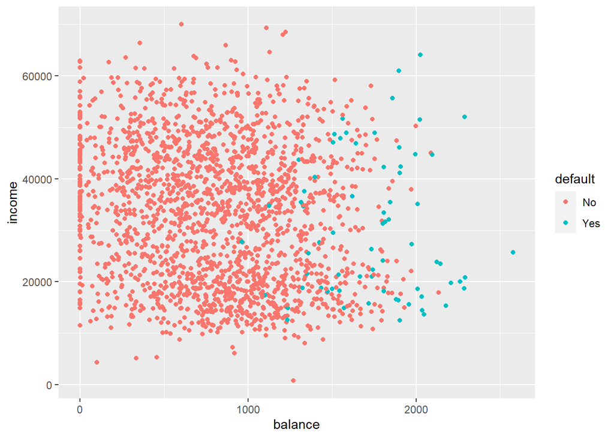

```r
default_test %>%
  ggplot(mapping = aes(x = balance, y = income, color = default)) +
  geom_point()
```

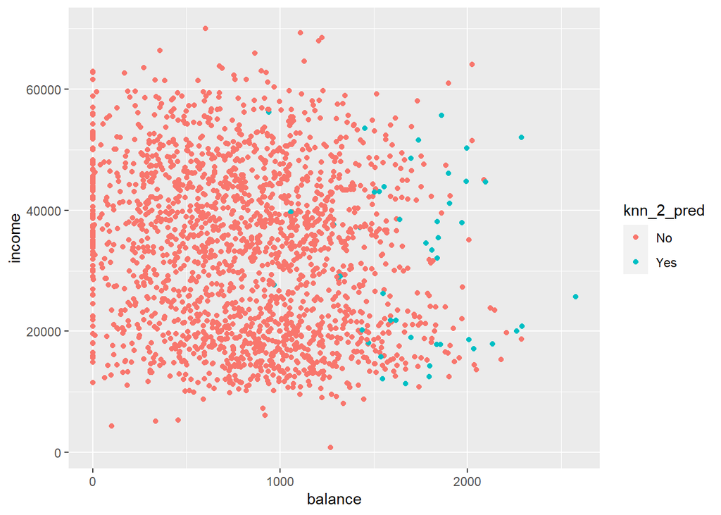

```r
default_test %>%
  ggplot(mapping = aes(x = balance, y = income, color = knn_2_pred)) +
  geom_point()
```

## Confusion matrix

```r
table(true = default_test$default, predicted = knn_2_pred)
```

```
##      predicted
## true    No  Yes
##   No  1899   31
##   Yes   55   15
```

7. **What would this confusion matrix look like if the classification were perfect?**

It would be a diagonal matrix.

8. **Make a confusion matrix for the 5-nn model and compare it to that of the 2-nn model. What do you conclude?**

```r
table(true = default_test$default, predicted = knn_5_pred)
```

```
##      predicted
## true    No  Yes
##   No  1922    8
##   Yes   61    9
```

They do not seem much different. The 5-nn model has more false negatives, but the 2-nn model has more false positives.

## Logistic regression

9. **Use `glm()` with argument family = binomial to fit a logistic regression model `lr_mod` to the `default_train` data.**

```r
lr_mod <- glm(formula = default ~ ., family = binomial(), data = default_train)
lr_mod
```

```
##
## Call:  glm(formula = default ~ ., family = binomial(), data = default_train)
##
## Coefficients:
## (Intercept)      student      balance       income
##  -1.114e+01   -4.956e-01    5.673e-03    1.156e-05
##
## Degrees of Freedom: 7999 Total (i.e. Null);  7996 Residual
## Null Deviance:       2314
## Residual Deviance: 1253  AIC: 1261
```

10. **Visualise the predicted probabilities versus observed class for the training dataset in `lr_mod`. You can choose for yourself which type of visualisation you would like to make. Write down your interpretations along with your plot.**

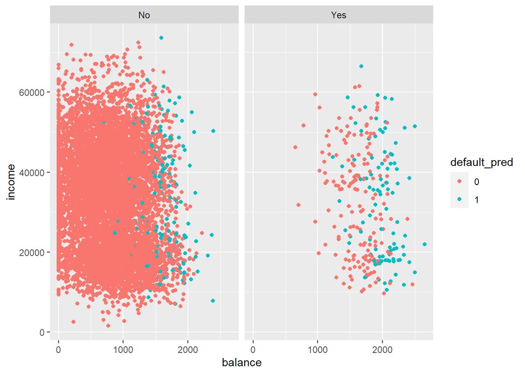

```r
log_pred <- predict(lr_mod, type = "response")

default_pred <- rbinom(length(log_pred), 1, log_pred)

default_train <-
  default_train %>%
  mutate(log_pred = log_pred) %>%
  mutate(default_pred = as.factor(default_pred))

default_train %>%
  ggplot(mapping = aes(x = balance, y = income)) +
  facet_wrap(default ~ .) +
  geom_point(mapping = aes(color = default_pred))
```

The prediction seems to be mostly correct for lower balances and very high balances, but it comes out incorrect for balances in the middle.

11. **Look at the coefficients of the `lr_mod` model and interpret the coefficient for `balance`. What would the probability of default be for a person who is not a student, has an income of 40000, and a balance of 3000 dollars at the end of each month? Is this what you expect based on the plots we’ve made before?**

```r
prob_spec <-
  default_train %>%
  filter(student == 0, 50000 > income, income > 40000, 3000 > balance, balance < 4000)
prob <- mean(prob_spec$log_pred)
prob * 100
```

```
## [1] 2.837882
```

### Visualising the effect of the balance variable

12. **Create a data frame called `balance_df` with 3 columns and 500 rows: `student` always 0, `balance` ranging from 0 to 3000, and `income` always the mean income in the `default_train` dataset.**

```r
student <- c(rep(0, times = 500))
balance <- c(seq(0, 3000, by=3001/500))
income <- c(rep(mean(default_train$income), times = 500))
balance_df <- data.frame(student = student, balance = balance, income = income)
```

13. **Use this dataset as the `newdata` in a `predict()` call using `lr_mod` to output the predicted probabilities for different values of `balance`. Then create a plot with the `balance_df$balance` variable mapped to x and the predicted probabilities mapped to y. Is this in line with what you expect?**

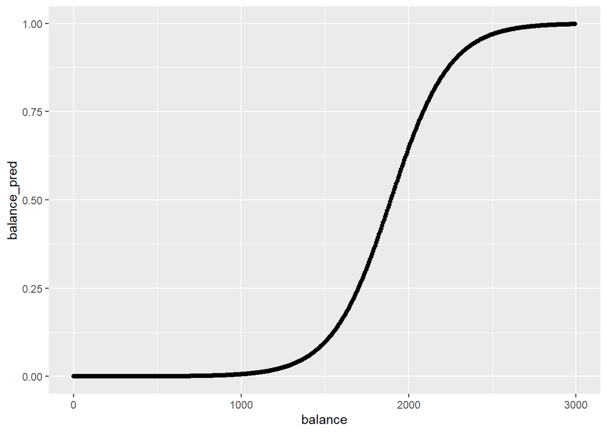

```r
balance_pred1 <- predict(lr_mod, newdata = balance_df, type = "response")

balance_df <-
  balance_df %>%
  mutate(balance_pred = balance_pred1)

balance_df %>%
  ggplot(mapping = aes(x = balance, y = balance_pred)) +
  geom_point()
```

14. **Create a confusion matrix just as the one for the KNN models by using a cutoff predicted probability of 0.5. Does logistic regression perform better?**

```r
table(true = default_train$default, predicted = ifelse(default_train$log_pred < 0.5, 0, 1))
```

```
##      predicted
## true     0    1
##   No  7705   32
##   Yes  184   79
```

## Linear discriminant analysis

15. **Train an LDA classifier lda_mod on the training set.**

```r
lda_mod <-
  lda(formula = default ~ ., data = default_train)
```

16. **Look at the `lda_mod` object. What can you conclude about the characteristics of the people who default on their loans?**

```r
lda_mod
```

```
## Call:
## lda(default ~ ., data = default_train)
##
## Prior probabilities of groups:
##       No      Yes
## 0.967125 0.032875
##
## Group means:
##       student   balance   income   log_pred default_pred1
## No  0.2888717  803.4652 33665.79 0.02202132    0.02404033
## Yes 0.3726236 1749.3143 32559.39 0.35217138    0.35741445
##
## Coefficients of linear discriminants:
##                         LD1
## student        1.622082e-04
## balance       -1.707793e-05
## income        -7.188420e-08
## log_pred       1.190655e+01
## default_pred1  1.247384e-01
```

Students are more likely to get yes on the default, but so are people with higher balance. As for the income, its seems to be about the same for both the people who get yes or no.

17. **Create a confusion matrix and compare it to the previous methods.**

```r
lda_pred <- predict(lda_mod)

table(true = default_train$default, predicted = lda_pred$class)
```

```
##      predicted
## true    No  Yes
##   No  7593  144
##   Yes  123  140
```

It seems worse.

## Final assignment

18. **Create a model (using knn, logistic regression, or LDA) to predict whether a 14 year old boy from the 3rd class would have survived the Titanic disaster. You can find the data in the data/ folder. Would the passenger have survived if they were a girl in 2nd class?**

```r
titanic <- read_csv("data/Titanic.csv")
split <- sample(rep(c("train", "test"), times = c(round(0.8*1313), round(0.2*1313))))
titanic <-
  titanic %>%
  mutate(split = split, PClass = ifelse(titanic$PClass == "1st", 1, ifelse(titanic$PClass == "2nd", 2, 3)), Sex = ifelse(titanic$Sex == "female", 1, 0))

titanic.train <-
  titanic %>%
  filter(split == "train") %>%
  select(-split) %>%
  drop_na()

titanic.test <-
  titanic %>%
  filter(split == "test") %>%
  select(-split) %>%
  drop_na()

titanic.knn <- knn(train = titanic.train %>% select(-Survived, -Name), test = titanic.test %>% select(-Survived, -Name), cl = titanic.train$Survived, k = 3)
titanic.knn
```

```
##   [1] 1 0 1 1 1 1 1 0 0 1 1 0 1 1 1 0 0 1 1 0 0 1 0 1 0 0 1 1 0 0 0 1 1 1 1 1 0
##  [38] 1 0 1 0 0 0 0 0 0 0 0 1 0 0 0 0 1 1 1 0 0 0 0 0 1 0 1 1 0 0 1 1 1 0 0 0 1
##  [75] 0 0 0 0 1 0 1 0 0 1 0 0 1 1 1 0 0 0 0 0 0 0 0 0 1 0 0 0 1 0 1 1 0 0 1 0 0
## [112] 0 0 0 0 1 0 0 0 0 0 0 1 0 0 0 0 0 0 0 1 0 0 0 0 0 0 0 0 0 1 0 0 0 1 0 0 1
## [149] 0 1 0 0 0
## Levels: 0 1
```

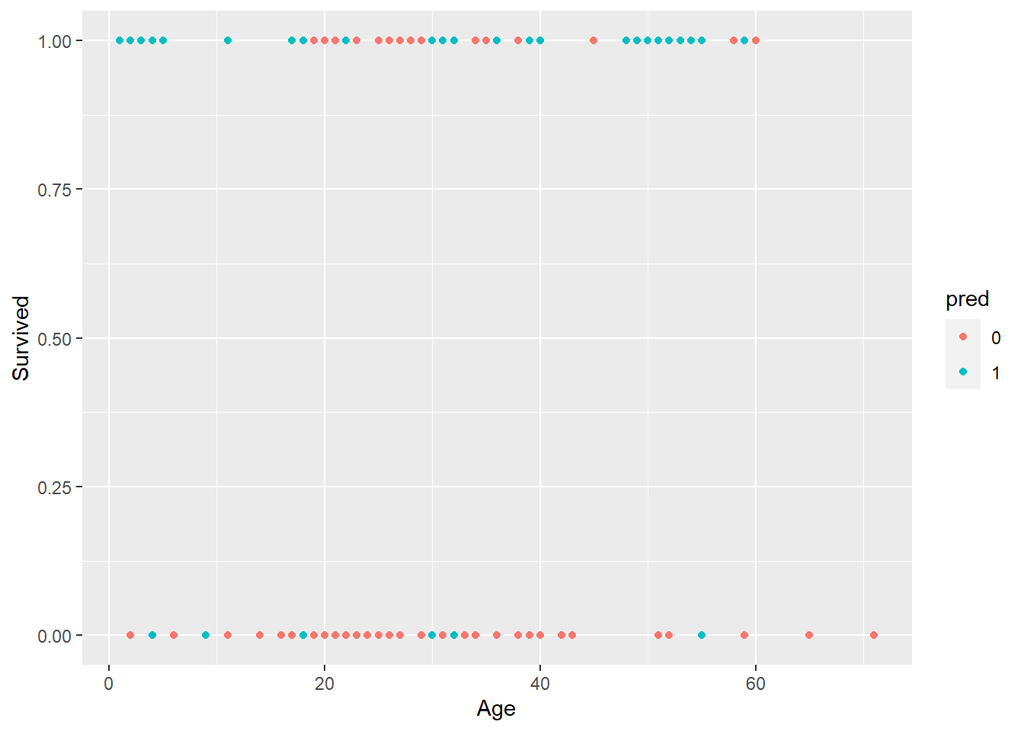

```r
titanic.pred <-
  titanic.test %>%
  mutate(pred = titanic.knn)

titanic.pred %>%
  ggplot(mapping = aes(x = Age, y = Survived, color = pred)) +
  geom_point()
```

Now, to predict for a 14 year old boy from the 3rd class:

```r
titanic <-
  read_csv("data/Titanic.csv") %>%
  select(-Name) %>%
  mutate(PClass = ifelse(titanic$PClass == "1st", 1, ifelse(titanic$PClass == "2nd", 2, 3)), Sex = ifelse(titanic$Sex == "female", 1, 0)) %>%
  drop_na()
titanic.boy <-
  data.frame(PClass = 3, Age = 14, Sex = 0)

titanic.knn <- knn(train = titanic %>% select(-Survived), test = titanic.boy, cl = titanic$Survived, k = 3)
titanic.knn
```

```
## [1] 0
## Levels: 0 1
```

He would not survive. Now for the 14 year old girl in 2nd class:

```r
titanic <-
  read_csv("data/Titanic.csv") %>%
  select(-Name) %>%
  drop_na() %>%
  mutate(PClass = ifelse(titanic$PClass == "1st", 1, ifelse(titanic$PClass == "2nd", 2, 3)), Sex = ifelse(titanic$Sex == "female", 1, 0))
titanic.girl <-
  data.frame(PClass = 2, Age = 14, Sex = 1)

titanic.knn <- knn(train = titanic %>% select(-Survived), test = titanic.girl, cl = titanic$Survived, k = 3)
titanic.knn
```

```
## [1] 0
## Levels: 0 1
```

She would not survive either.